# Brain tumor detector

## Nutshell

As of now this project is under development.

In this project I build a program that detects and localizes cancer from images of human brains, as explained on the course *Modern Artificial Intelligence*, lectured by Dr. Ryan Ahmed, Ph.D. MBA.

The program will train two models which will

1. classify the images either containing cancer tumor or not
2. localizes the tumor within the brain

```
/content/drive/MyDrive/Colab Notebooks/brain-tumor-detector/Brain_MRI
```

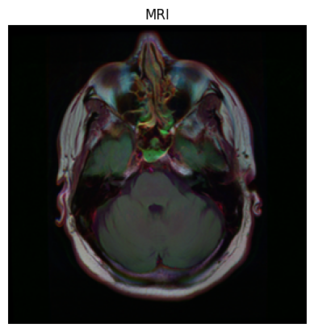

# Introduction to the Brain Tumor Detection

Deep learning has proven to be as good and even better than humans in detecting diseases from X-rays, MRI scans and CT scans. there is huge potential in using AI to speed up and improve the accuracy of diagnosis. This project will use the labeled dataset from https://www.kaggle.com/datasets/mateuszbuda/lgg-mri-segmentation which consists of 3929 Brain MRI scans and the tumor location. The final pipeline has a two step process where

1. A **Resnet deep learning classifier model** will classify the input images into two groups: tumor detected and tumor not detected.
2. For the images, where tumor was detected, a second step is performed, where a **ResUNet segmentation model** detects the tumor location on the pixel level.

## Image segmentation

Image segmentation extracts information from images on the level of pixels. It is used for object recognition and localization in applications like medical imaging and self-driving cars. Image segmentation **produces a pixel-wise mask** of the image with deep learning approaches using common architectures such as CNN, FNNs and Deep Encoders-Decoders.

With Unet, the input and the output have the same size so the size of the images is preserved. In contrast to the CNN image classification, where the image is converted to a vector and the entire image is classified as a class label, the Unet performs classification on pixel level. Unet formulates a loss function for every pixel and then a softmax function is applied to every pixel. In other words, the segmentation problem is solved as a classification problem.

# Looking into the data

We have a csv file that contains the patient IDs, the locations of the images, their masks and indicator if there is a tumor in the image (1 - tumor, 0 - healthy). There are 1373 images with tumors and 2556 healthy brain images. Thus, the dataset is imbalanced.

```
<class 'pandas.core.frame.DataFrame'>
RangeIndex: 3929 entries, 0 to 3928
Data columns (total 4 columns):
 #   Column      Non-Null Count  Dtype
---  ------      --------------  -----
 0   patient_id  3929 non-null   object
 1   image_path  3929 non-null   object
 2   mask_path   3929 non-null   object
 3   mask        3929 non-null   int64
dtypes: int64(1), object(3)
memory usage: 122.9+ KB
```

|  | patient_id | image_path | mask_path | mask |
| --- | --- | --- | --- | --- |
| 0 | TCGA_CS_5395_19981004 | TCGA_CS_5395_19981004/TCGA_CS_5395_19981004_1.tif | TCGA_CS_5395_19981004/TCGA_CS_5395_19981004_1_... | 0 |
| 1 | TCGA_CS_5395_19981004 | TCGA_CS_4944_20010208/TCGA_CS_4944_20010208_1.tif | TCGA_CS_4944_20010208/TCGA_CS_4944_20010208_1_... | 0 |
| 2 | TCGA_CS_5395_19981004 | TCGA_CS_4941_19960909/TCGA_CS_4941_19960909_1.tif | TCGA_CS_4941_19960909/TCGA_CS_4941_19960909_1_... | 0 |
| 3 | TCGA_CS_5395_19981004 | TCGA_CS_4943_20000902/TCGA_CS_4943_20000902_1.tif | TCGA_CS_4943_20000902/TCGA_CS_4943_20000902_1_... | 0 |
| 4 | TCGA_CS_5395_19981004 | TCGA_CS_5396_20010302/TCGA_CS_5396_20010302_1.tif | TCGA_CS_5396_20010302/TCGA_CS_5396_20010302_1_... | 0 |

```python
brain_df.mask_path[1] # Path to the brain MRI image
```

```
'TCGA_CS_4944_20010208/TCGA_CS_4944_20010208_1_mask.tif'
```

```python
brain_df.image_path[1] # Path to the segmentation mask
```

```
'TCGA_CS_4944_20010208/TCGA_CS_4944_20010208_1.tif'
```

| mask | count |
| --- | --- |
| 0 | 2556 |
| 1 | 1373 |

**dtype:** int64

## Visualisation of the datasets

[interactive chart not shown]

Below is an exmaple of an MRI image and the matching mask. This example has a small tumor. In images where no tumor is present, the mask will be complety black.

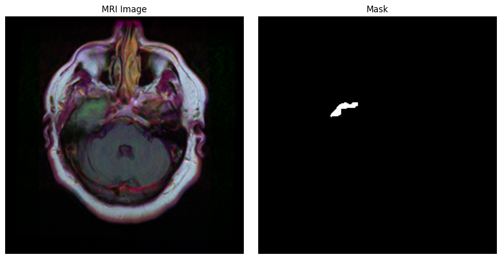

Below are visualisations from 6 MRIs and their overlayed masks in rose color.

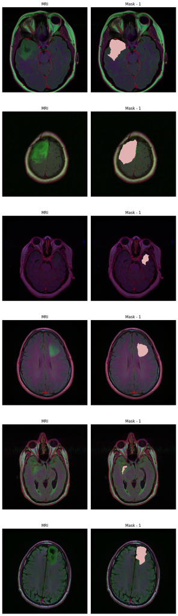

# Convolutional neural networks (CNNs)

- The first CNN layers are used to extract high level general features
- The last couple of layers will perform classification
- Locla respective fields scan the image first searching for simple shapes such as edges and lines
- The edges are picked up by the subsequent layer to form more complex features Good visualisation of the feature extraction with convolutions can be found at https://setosa.io/ev/image-kernels/

# ResNet (Residual Network)

- As CNNs grow deeper, vanishing gradients negatively imapct the network performance. Vanishing gradient occurs when the gradient is backpropagated to earlier layers which results in a very small gradient.
- ResNets "skip connection" feature can allow training of 152 layers wihtout vanishing gradient problems
- ResNet adds "identity mapping on top of the CNN
- ResNet deep network is trained with ImageNet, which contains 11 million images and 11 000 categories

ResNet paper (He etal, 2015): https://arxiv.org/pdf/1512.03385

AS seen in the Figure 6. from the Resnet paper, the ResNet architectures overcome the training challenges from deep networks compared ot the plain networks. ResNet-152 achieved 3.58% error rate on the ImageNet dataset. This is better than human performance.

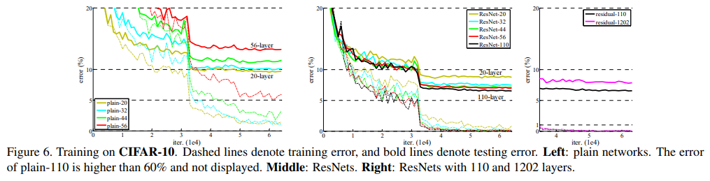

```python
!git status -sb
!git add .gitignore
```

```
## main...origin/main [ahead 3]
M  .gitignore
M  docs/index.html
A  docs/pics/concept.jpg
A  docs/pics/plain_network.png
A  docs/pics/resnetwork.png
MM master.ipynb
M  master_tagged.ipynb
```

[output not shown]

[output not shown]